# Test na proporcję

Tomasz Stąpor

4 September 2014

Eksperyment z astrologami wedyjskimi. Jest 40 horoskopów, z których 20 nalezy do dzieci upośledzonych umysłowo i 20 horoskopów do dzieci z wybitnymi osiągnięciami. Trzeba przydzielić horoskopy do każdej tych grup. Prawdopodobieństwo oczekiwane to 1/2. Najgorszy z astrologów osiągnął wynik 17 trafień na 40 horoskopów.

### Test lewo, prawo i obustronny

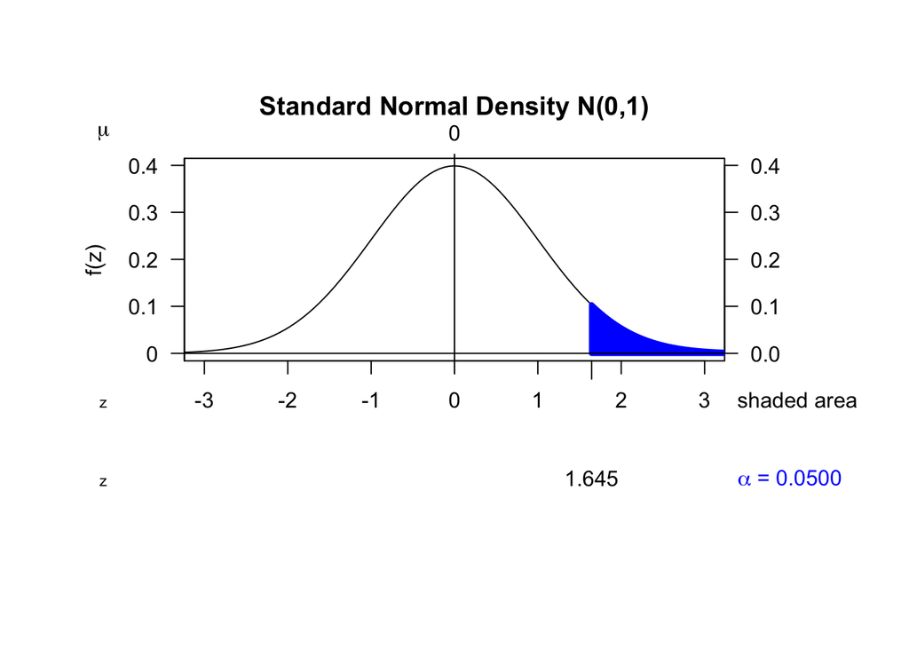

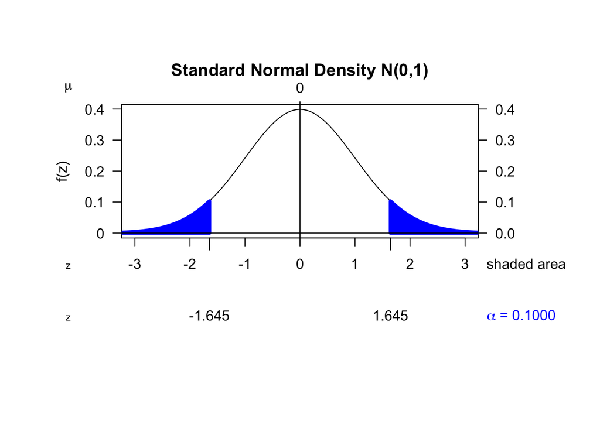

Załóżmy, że sprawdzamy średnią, w tym przypadku 17 na 40 strzałów. Jak to wypada na graficznej prezentacji testu statystycznego:

[figure not shown]

Najlepszy 24 dobre trafienia na 40 horoskopów.

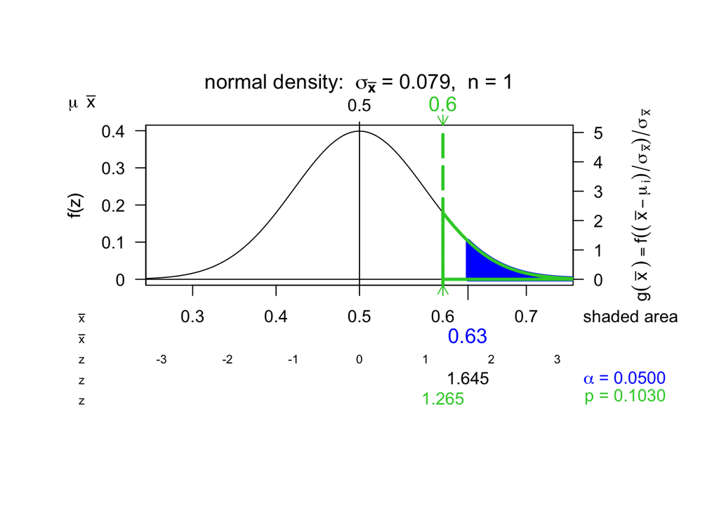

Można powiedzieć, że gdyby strzelił 26 na 40, to byłby na granicy poziomu istotności 0,05.

Dokładne testy robi się z alfa = 0,01 procent, zo zmniejsza pole w jakie może wpaść wynik.

W takim przypadku, żeby nikt nie miał wątpliwości trzeba dobrze trafić 28 na 40 horoskopów.